# Migration studies with a Compositional Data approach: a case study of population structure in the Capital Region of Denmark

**Authors:** Javier Elío[^1], Marina Georgati[^2], Henning S. Hansen[^3], Carsten Keßler[^4].

# Prerequisites

The data have been analysed with **R** (version 4.1.2) and **Rstudio** (version 1.4.1717).

```r
# List of packages
my_pkgs <- c("compositions",
             "broom",
             "data.table", "danstat", "dint",
             "furrr",
             "ggspatial", "gtsummary", "ggtern",
             "kableExtra", "knitr",
             "modelr",
             "patchwork", "papeR", "performance",
             "rmarkdown", "remotes",
             "sf", "spdep",
             "tricolore",
             "units",
             "viridis",
             "tidyverse", "tidytable", "tm")

# Load packages
lapply(my_pkgs, require, character.only = TRUE)

# Install ggsflabel from GitHub
if(!require("ggsflabel")) devtools::install_github("yutannihilation/ggsflabel")
library(ggsflabel)
```

Set ggplot theme.

```r
# Set theme for ggplot ----
theme_set(theme_bw() +
            theme(plot.title = element_text(face = "bold", size = 9),
                  legend.title = element_text(face = "bold", size = 7),
                  legend.text = element_text(size = 7),
                  axis.text = element_text(size = 7),
                  plot.subtitle = element_text(size = 7),
                  axis.title = element_text(size = 7)))
```

# Data

## Administrative units

Parishes of the Capital region downloaded from [kortforsyningen](https://kortforsyningen.dk/). We have created our own package for downloading the data a local repository directly from R (i.e. [dangeo](https://github.com/javiereliomedina/dangeo.git)). The package can be downloaded from GitHub:

```r
# Install packages from GitHub
if(!require("devtools"))  install.packages("devtools")

if (!require("dangeo"))  remotes::install_github("javiereliomedina/dangeo")
library(dangeo)
```

Although the *kortforsyningen* data are free, a *username* and a *password* is needed ([“Opret ny bruger”](https://kortforsyningen.dk/indhold/min-side-0)). By default **dangeo** looks for credentials on `.Renviron` as: `kortforsyningen_id = "username"` and `kortforsyningen_pwd = "password"`. You would need to save them with `usethis::edit_r_environ()`:

```r
# Set username and password
# usethis::edit_r_environ() # Open .Renviron file, and save the username (kortforsyningen_id = "your_username") and password (kortforsyningen_pwd = "your_password")
```

You would also need to define with `dangeo_set_param()` the local directory where the data are downloaded (`loc_dir`). It is defined as `loc_dir = rappdirs::user_cache_dir()`, although it can be changed `loc_dir = “./your/local/path”`. The first time a file is downloaded with `dangeo_get_data()`, the process can be time consuming (there are some very big files). However, it will not be downloaded in subsequent calls if the files is already in the local directory (the dataset can be overwritten be setting `overwrite = TRUE` on `dangeo_get_data()`). Once we have our *username* and *password*, and we have define the local repository for the data, we should set them on our R-session:

```r
# Set local repository and password to kortforsyningen
dangeo_set_param()
```

Load data:

```r
# Download DAGI (scale 1:10000)
dangeo_get_data(ftp_folder = "landinddelinger/dagi/SHAPE",
                zip_name   = "DAGIREF_SHAPE_UTM32-EUREF89.zip")

# Municipalities (get from DAGI)
muni_link <- paste(loc_dir,
                   "DAGIREF_SHAPE_UTM32-EUREF89/ADM",
                   "KOMMUNE.shp",
                   sep = "/")
dk_muni  <- read_sf(muni_link) %>%
  st_zm() %>%
  st_transform(crs = "EPSG:25832") %>%
  select(KOMKODE, KOMNAVN) %>%
  rename(muni_id = KOMKODE,
         muni_name = KOMNAVN) %>%
  group_by(muni_id, muni_name) %>%
  summarise(geometry = sf::st_union(geometry)) %>%
  ungroup() %>%
  # Calculate the area of each municipalitie (km2)
  mutate(area_km2 = as.numeric(units::set_units(st_area(.), km^2)))

# Country
dk_country <- st_union(dk_muni)

# Codes of the communes under study
cptl_muni <- c("København",
               "Frederiksberg",
               "Albertslund",
               "Ballerup",
               "Brøndby",
               "Dragør",
               "Gentofte",
               "Gladsaxe",
               "Glostrup",
               "Herlev",
               "Høje-Taastrup",
               "Hvidovre",
               "Ishøj",
               "Lyngby-Taarbæk",
               "Rødovre",
               "Tårnby",
               "Vallensbæk")

# Select municipalities under study
cptl_muni <- dk_muni %>% filter(muni_name %in% cptl_muni)

dk_country_crop <- st_crop(dk_country, cptl_muni)

# Parishes polygons of Denmark, and select those in the study area
prsh_link <- paste(loc_dir,
                   "DAGIREF_SHAPE_UTM32-EUREF89/ADM",
                   "SOGN.shp",
                   sep = "/")
dk_prsh  <- read_sf(prsh_link) %>%
  st_zm() %>%
  st_transform(crs = "EPSG:25832")

# Select those where the centroid is in the capital region
dk_prsh_cent <- st_centroid(dk_prsh)
cptl_prsh_cent <- st_intersection(dk_prsh_cent, cptl_muni)

cptl_prsh <- dk_prsh %>%
  # Get parishes in the capital region
  filter(SOGNEKODE %in% cptl_prsh_cent$SOGNEKODE) %>%
  # Combine several parish features geometries into one polygon
  group_by(SOGNEKODE, SOGNENAVN) %>%
  summarise(geometry = st_union(geometry)) %>%
  ungroup() %>%
  # add area of the parish (in km2)
  mutate(prsh_area_km2 = as.numeric(units::set_units(st_area(.), km^2))) %>%
  # Translate column names
  rename(prsh_id = SOGNEKODE,
         prsh_name = SOGNENAVN)

# Contour of the capital region (merge the parishes in one polygon):
cptl_area <- cptl_prsh %>%
  st_union() %>%
  st_sf() %>%
  st_transform(crs = "EPSG:25832")
```

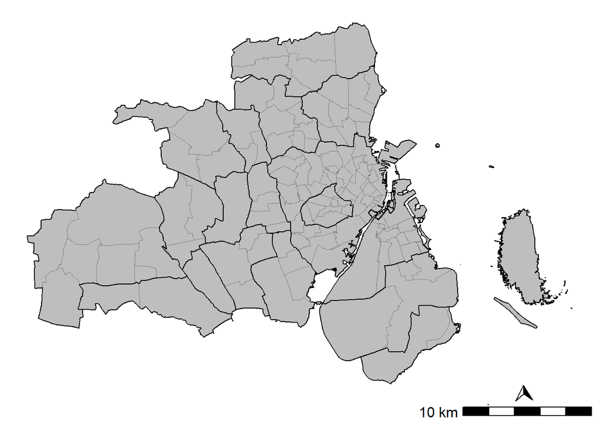

Study area

```r
ggplot() +
  geom_sf(data = cptl_prsh,
          fill = "grey",
          color = "grey50",
          size = 0.05) +
  geom_sf(data = cptl_muni,
          fill = NA,
          color = "black",
          size = 0.5) +
  theme_void() +
  annotation_scale(location = "br", text_cex = 1) +
  annotation_north_arrow(location = "br",
                         pad_x = unit(2, "cm"),
                         pad_y = unit(0.65, "cm"),
                         which_north = "true",
                         height = unit(0.5, "cm"),
                         width = unit(0.5, "cm"),
                         style = north_arrow_orienteering(text_col = "white",
                                                          text_size = 1))
```

## Population data at parish level

Population data were uploaded from Denmark Statistics (i.e. Table [KMSTA001: Population 1. January by parish, ancestry and National Church](https://www.statbank.dk/statbank5a/SelectVarVal/Define.asp?MainTable=KMSTA001&PLanguage=1&PXSId=0&wsid=cftree)).

```r
## Auxiliary functions for reading the data with the package *danstat*

# Loop by year for getting DST data
  steps <- function(year){
    var_values <- list(id_region, id_ancestry, year)
    var_input <- purrr::map2(.x = var_codes,
                             .y = var_values,
                             .f = ~list(code = .x, values = .y))
    get_data(id_table, variables = var_input)
  }
```

```r
## Read and clean table KMSTA001

# Table
id_table <- "KMSTA001"
var_pop <- get_table_metadata(table_id = id_table, variables_only = TRUE)

# Codes for var_input
var_codes <- c("SOGN", "HERKOMST", "Tid")

# Values for var_input
# Region: parishes of the study area (i.e. cptl_parish)
id_region <- cptl_prsh$prsh_id
# Ancestry
id_ancestry <- NA
# Quarters
id_year <- 2020  # vector with years

# Read data (n parallel)
plan(multisession, workers = 7)
cptl_prsh_ancestry_read <- id_year %>%
  future_map_dfr(steps)
plan("default")

# Clean data
cptl_prsh_ancestry <- cptl_prsh_ancestry_read %>%
  # Translate column names into English
  rename(parish = SOGN,
         ancestry = HERKOMST,
         year = TID,
         value = INDHOLD) %>%
  # Get parish codes, names, and municipality names
  separate(parish,
           c("prsh_id", "prsh_name", "muni_name"),
           sep = " ",
           extra = "drop") %>%
  mutate(muni_name = gsub("\\(", "", muni_name)) %>%
  # Make shorter names in ancestry
  mutate(ancestry = case_when(
    ancestry == "Persons of Danish origin" ~ "pop_dan",
    ancestry == "Immigrants from western countries" ~ "pop_mi_wst",
    ancestry == "Immigrants from non-western countries" ~ "pop_mi_nwst",
    ancestry == "Descendants from western countries" ~ "pop_de_wst",
    ancestry == "Descendants from non-western countries" ~ "pop_de_nwst"),
    ancestry = factor(ancestry)) %>%
  # Pivot (one row for peach parish and year)
  pivot_wider(names_from = ancestry, values_from = value) %>%
  # Merge immigrants and their descendants (i.e. foreigners)
  mutate(pop_frgn_wst = pop_mi_wst + pop_de_wst,
         pop_frgn_nwst = pop_mi_nwst + pop_de_nwst) %>%
  # Add column with total population
  mutate(pop_total = pop_dan + pop_frgn_wst + pop_frgn_nwst)

# Add the spatial information:
cptl_prsh_ancestry_sf <- cptl_prsh %>%
  select(prsh_id, prsh_area_km2) %>%
  left_join(cptl_prsh_ancestry, by = c("prsh_id")) %>%
  # Population density
  mutate(across(starts_with("pop"), ~.x/prsh_area_km2, .names = "{.col}_km2")) %>%
  # Population in percentage
  mutate(across(.cols = c(pop_dan, pop_frgn_wst, pop_frgn_nwst, pop_total),
                .fns = ~ 100 * .x / pop_total,
                .names = "{.col}_pct"))
```

## Housing price

We have got the housing prices from the Building and Dwelling Register ([BBR](https://teknik.bbr.dk/forside)). The individual data are not free and we have therefore only saved here the summary statistics (i.e. mean and media values).

```r
sum_runits_oft_prices <- readRDS("sum_runits_oft_prices.rds") %>%
  # Remove NAs
  drop_na() %>%
  # sf objects
  st_sf()
```

# Analysis

## Population at parish level

Distribution of Danes, Western, and non-Western population (in percentage over the total population in the parish).

```r
cptl_prsh_ancestry_sf %>%
  as_tibble() %>%
  select(pop_dan_pct, pop_frgn_nwst_pct, pop_frgn_wst_pct, -geometry) %>%
  rename(Danes = pop_dan_pct,
         Non_Western = pop_frgn_nwst_pct,
         Western = pop_frgn_wst_pct) %>%
  pivot_longer(cols = everything(),
               names_to = "names",
               values_to = "value") %>%
  # Summary values
  tbl_summary(by = names,
              type = all_continuous() ~ "continuous2",
              statistic = all_continuous() ~ c("{mean}",
                                               "{median}",
                                               "{p25} - {p75}",
                                               "{min} - {max}"),
              missing = "no",
              digits = all_continuous() ~ 1) %>%
  bold_labels()
```

| **Characteristic** | **Danes**, N = 127 | **Non_Western**, N = 127 | **Western**, N = 127 |
| --- | --- | --- | --- |
| value |  |  |  |
| Mean | 77.8 | 14.5 | 7.7 |
| Median | 79.6 | 11.5 | 7.1 |
| IQR | 72.9 - 84.3 | 7.7 - 17.7 | 4.9 - 9.7 |
| Range | 21.2 - 94.6 | 2.7 - 69.9 | 2.7 - 19.9 |

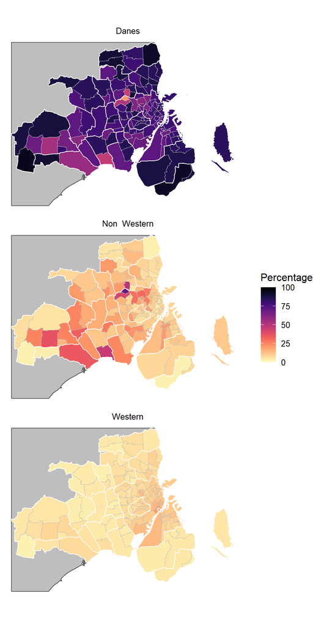

Population distribution

```r
cptl_prsh_ancestry_sf %>%
  select(pop_dan_pct, pop_frgn_nwst_pct, pop_frgn_wst_pct) %>%
  rename(Danes = pop_dan_pct,
         Non_Western = pop_frgn_nwst_pct,
         Western = pop_frgn_wst_pct) %>%
  pivot_longer(cols = -geometry,
               names_to = "names",
               values_to = "value") %>%
  st_sf() %>%
  ggplot() +
  geom_sf(data = dk_country_crop, fill = "grey") +
  geom_sf(aes(fill = value ), color = "grey", size = 0.05) +
  geom_sf(data = cptl_muni, fill = NA, color = "white", size = 0.5) +
  scale_fill_viridis(name = "Percentage",
                     option = "magma",
                     direction = -1,
                     limits = c(0, 100)) +
  theme_void() +
  facet_wrap(~names, ncol = 1)
```

## Housing price

Spatial distribution of median values.

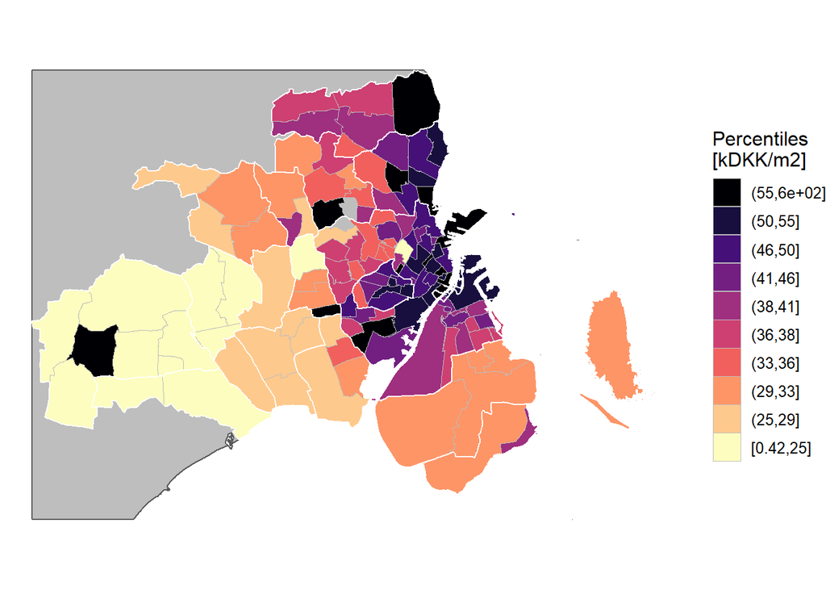

Median house prices in the ordinary free trade

```r
ggplot() +
  geom_sf(data = dk_country_crop, fill = "grey") +
  geom_sf(data = sum_runits_oft_prices,
          aes(fill = cut_number(median_kDKK_m2,
                                n = 10,
                                ordered_result = TRUE,
                                dig.lab = 0)),
          color = "grey",
          size = 0.05) +
  geom_sf(data = cptl_muni, fill = NA, color = "white", size = 0.5) +
  scale_fill_viridis_d(name = "Percentiles\n[kDKK/m2]",
                     option = "magma",
                     direction = -1) +
  labs(x = "",
       y = "") +
  theme_void() +
  guides(fill = guide_legend(reverse = TRUE))
```

The summary descriptive statistics of the housing prices by parishes:

```r
# Create variable labels of the variables to be printed in the table
labelled::var_label(sum_runits_oft_prices$n_runits_oft)   <- "N. houses in the ordinary free trade"
labelled::var_label(sum_runits_oft_prices$mean_kDKK_m2)   <- "Mean (kDKK/m2)"
labelled::var_label(sum_runits_oft_prices$median_kDKK_m2) <- "Median (kDKK/m2)"

# Summary table
sum_runits_oft_prices %>%
  as_tibble() %>%
  # Select variables of interest
  select(n_runits_oft, mean_kDKK_m2,  median_kDKK_m2) %>%
  # Summary values
  tbl_summary(type = all_continuous() ~ "continuous2",
              statistic = all_continuous() ~ c("{mean}",
                                               "{median}",
                                               "{p25} - {p75}",
                                               "{min} - {max}"),
              missing = "no",
              digits = all_continuous() ~ 1) %>%
  bold_labels()
```

| **Characteristic** | **N = 125** |
| --- | --- |
| N. houses in the ordinary free trade |  |
| Mean | 150.1 |
| Median | 127.0 |
| IQR | 85.0 - 182.0 |
| Range | 7.0 - 637.0 |
| Mean (kDKK/m2) |  |
| Mean | 82.8 |
| Median | 42.3 |
| IQR | 33.2 - 61.2 |
| Range | 22.1 - 1,132.9 |
| Median (kDKK/m2) |  |
| Mean | 46.2 |
| Median | 38.0 |
| IQR | 31.1 - 47.4 |
| Range | 0.4 - 602.6 |

## Compositional data analysis

Ternary representation of population distribution.

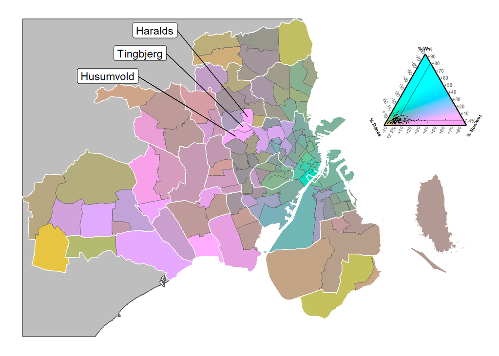

Population distribution in 2020

```r
# Make colours
tric <- tricolore::Tricolore(cptl_prsh_ancestry_sf,
                             p1 = "pop_dan",
                             p2 = "pop_frgn_wst",
                             p3 = "pop_frgn_nwst",
                             breaks = Inf,
                             show_data = FALSE,
                             center = NA,
                             hue = 2/12,
                             lightness = 1,
                             chroma = 1)

# Add columns with colours
cptl_prsh_ancestry_sf <- mutate(cptl_prsh_ancestry_sf, pop_rgb = tric$rgb)

# Legend
p_legend <- tric$key +
  geom_point(data = cptl_prsh_ancestry_sf,
             aes(x = pop_dan, y = pop_frgn_wst, z = pop_frgn_nwst),
             shape = 16,
             size = 0.2) +
  labs(L = "% Danes",
       T = "% Wst",
       R = "% Non-wst") +
  theme(axis.title = element_text(size = 5, face = "bold"),
        axis.text  = element_text(size = 5))

# Label Husumvold, Haralds and Tingbjerg
prsh_lbls <- cptl_prsh_ancestry_sf %>%
  filter(prsh_name %in% c("Husumvold", "Haralds", "Tingbjerg"))

# Map
ggplot() +
  geom_sf(data = dk_country_crop,
          aes(geometry = geometry),
          fill = "grey") +
  geom_sf(data = cptl_prsh_ancestry_sf,
          aes(fill = pop_rgb, geometry = geometry),
          size = 0.05) +
  scale_fill_identity() +
  geom_sf(data = cptl_muni,
          aes(geometry = geometry),
          fill = NA,
          color = "white",
          size = 0.5) +
  geom_sf_label_repel(data = prsh_lbls,
                      aes(label = prsh_name),
                      force = 15,
                      nudge_y =   7000,
                      nudge_x = -10000,
                      seed = 15) +
  theme_void() +
  annotation_custom(ggtern::ggplotGrob(p_legend) ,
                    xmin =  730000,
                    xmax =  742000,
                    ymin = 6178000,
                    ymax = 6190000)
```

### Balances

Transform data to CoDa format.

```r
# Transform to CoDa format
dat_acomp <- cptl_prsh_ancestry_sf %>%
  select(prsh_id, pop_dan, pop_frgn_nwst, pop_frgn_wst) %>%
  rename(dan = pop_dan,
         nwst = pop_frgn_nwst,
         wst = pop_frgn_wst) %>%
  as_tibble() %>%
  drop_na() %>%
  select(-geometry) %>%
  # Close dataset
  clo(parts = c("dan", "nwst", "wst"),
      total = 100) %>%
  # CoDa
  acomp()
```

PCA with clr transformations.

```r
# PCA
pc <- princomp(dat_acomp)

pca_importance <- function(x) {
  vars <- x$sdev^2
  vars <- vars/sum(vars)
  rbind("Standard deviation" = x$sdev,
        "Proportion of Variance" = vars,
        "Cumulative Proportion" = cumsum(vars))
}

pca_importance(summary(pc)) %>%
  kbl(caption = "Importance of components",
      digits = 3) %>%
  kable_styling()
```

Importance of components

|  | Comp.1 | Comp.2 |
| --- | --- | --- |
| Standard deviation | 0.574 | 0.353 |
| Proportion of Variance | 0.726 | 0.274 |
| Cumulative Proportion | 0.726 | 1.000 |

Biplot and balance-dendrogram:

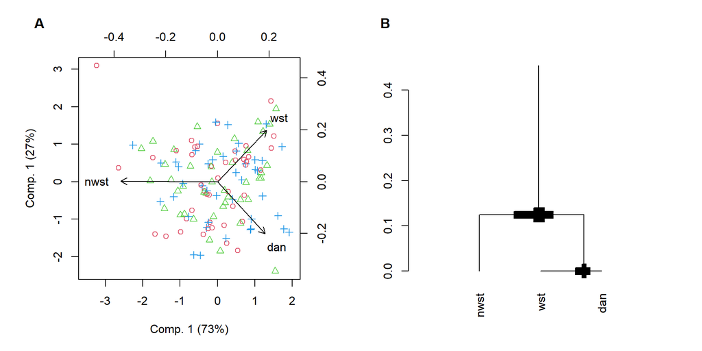

Biplot of clr transfomation and balance dendrogram

```r
par(mfrow = c(1, 2))
coloredBiplot(x = pc,
              pc.biplot = T,
              xlabs.pc = c(1, 2, 3),
              xlabs.col = 2:4,
              col = "black",
              xlab = "Comp. 1 (73%)",
              ylab = "Comp. 1 (27%)",
              xlim = c(-3.5, 2))
title(outer = T,
      adj = 0.05,
      main = "A",
      cex = 1.1,
      col = "black",
      font = 2,
      line = -2)

# Dendrogram balances
signary <- t(matrix( c(1, -1,  1,
                       1,  0, -1),
                     ncol = 3,
                     nrow = 2,
                     byrow = TRUE))
CoDaDendrogram(X = dat_acomp,
               signary = signary,
               col = "black",
               main = "CoDa Dendrogram")
title(outer = T,
      adj = 0.55,
      main = "B",
      cex = 1.1,
      col = "black",
      font = 2,
      line = -2)
```

Add balances (b1 and b2) to the dataset:

```r
cptl_prsh_ancestry_sf <- cptl_prsh_ancestry_sf %>%
  mutate(b1 = sqrt(2/3) * log( ((pop_dan * pop_frgn_wst)^0.5) / (pop_frgn_nwst)),
         b2 = sqrt(1/2) * log(pop_dan / pop_frgn_wst))
```

Higher values of b1 indicate less non-Western population while higher values of b2 indicate less western migrants:

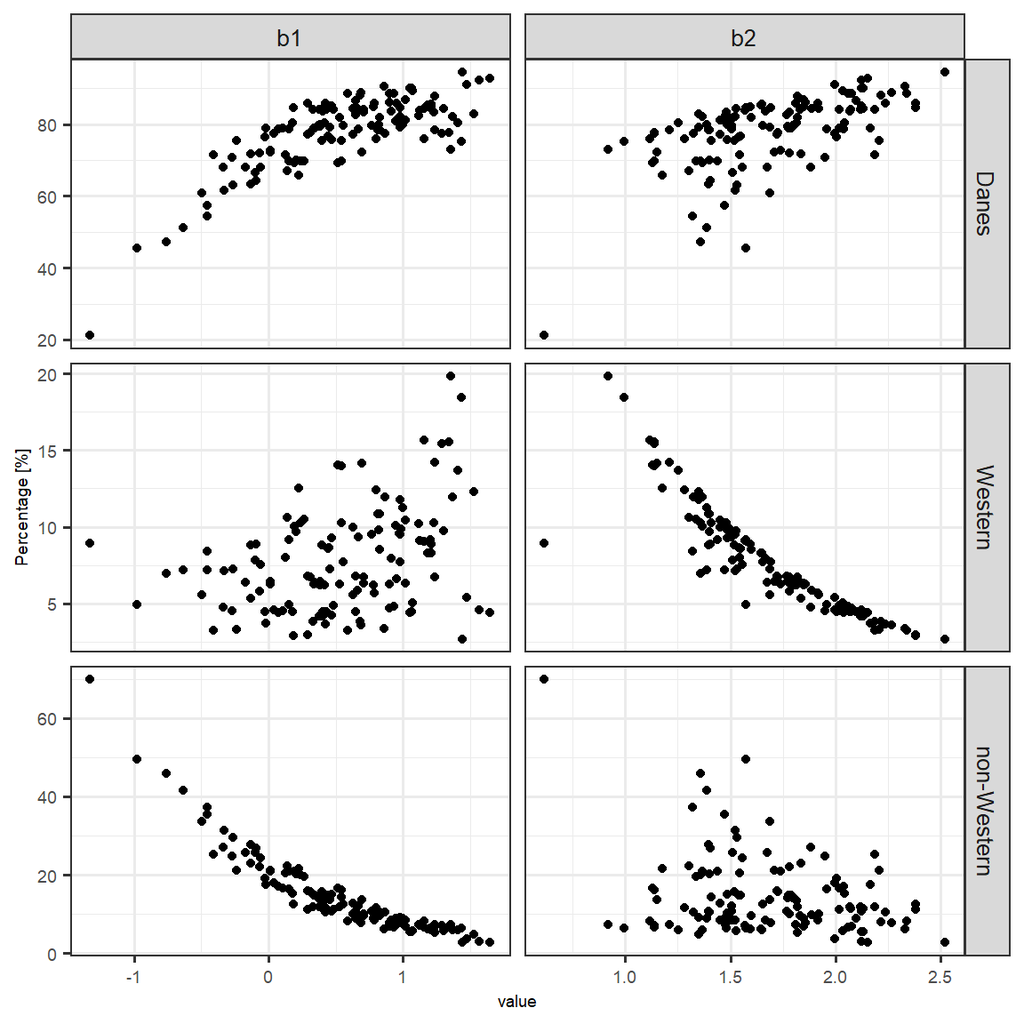

Non-Western population vs. balance 1

```r
cptl_prsh_ancestry_sf %>%
  as_tibble() %>%
  select(pop_dan_pct, pop_frgn_wst_pct, pop_frgn_nwst_pct, b1, b2, -geometry) %>%
  pivot_longer(cols = -c(b1, b2),
               names_to = "pop",
               values_to = "percentage") %>%
  pivot_longer(cols = -c(pop, percentage),
               names_to = "balance",
               values_to = "value") %>%
  mutate(pop = factor(pop,
                      levels = c("pop_dan_pct",
                                 "pop_frgn_wst_pct",
                                 "pop_frgn_nwst_pct"),
                      labels = c("Danes",
                                 "Western",
                                 "non-Western"))) %>%
  ggplot() +
  geom_point(aes(x = value,
                 y = percentage)) +
  labs(y = "Percentage [%]") +
  facet_grid(pop ~ balance, scales = "free")
```

### Spatial autocorrelation of balances

Global Moran index:

```r
# Moran
nb <- poly2nb(cptl_prsh_ancestry_sf, queen = TRUE)
wts <- nb2listw(nb, style = "W", zero.policy = TRUE)

# Global index
GMI_b1 <- moran.test(cptl_prsh_ancestry_sf$b1, listw = wts) %>%
  tidy() %>%
  mutate(balance = "b1") %>%
  select(balance, everything()) %>%
  rename(moran_I  = estimate1,
         expectation = estimate2,
         variance = estimate3)

GMI_b2 <- moran.test(cptl_prsh_ancestry_sf$b2, listw = wts) %>%
  tidy() %>%
  mutate(balance = "b2") %>%
  select(balance, everything()) %>%
  rename(moran_I  = estimate1,
         expectation = estimate2,
         variance = estimate3)

bind_rows(GMI_b1, GMI_b2) %>%
  kbl(caption = "Spatial autocorrelation of balances",
      digits = c(rep(3, 5), 32)) %>%
  kable_styling()
```

Spatial autocorrelation of balances

| balance | moran_I | expectation | variance | statistic | p.value | method | alternative |
| --- | --- | --- | --- | --- | --- | --- | --- |
| b1 | 0.470 | -0.008 | 0.003 | 8.563 | 5.502511e-18 | Moran I test under randomisation | greater |
| b2 | 0.542 | -0.008 | 0.003 | 9.837 | 3.915499e-23 | Moran I test under randomisation | greater |

Local Moran index:

```r
# Local Moran index

f_local_moran <- function(year,
                          variable,
                          df = cptl_prsh_ancestry_sf,
                          signif = 0.15) {

  # Polygons
  s <- df %>%
    # Select
    filter(year == {{ year }}) %>%
    drop_na() %>%
    st_sf()

  # Variable
  x <- s %>%
    # Variable
    pull( {{ variable }})

  # Plot MI
  xp <- x %>%
    # Local Index
    localmoran_perm(listw = nb2listw(poly2nb(s, queen = TRUE),
                                     style = "W",
                                     zero.policy = TRUE),
                    nsim = 999) %>%
    as_tibble() %>%
    dplyr::rename(p.value = `Pr(z > 0)`) %>%
    # binds results to our polygon shapefile
    cbind(s) %>%
    st_sf() %>%
    # center the variable of interest around its mean
    mutate(m_qualification = x - mean( x ),
           m_local = Ii - mean(Ii)) %>%
    # Build quadrant
    mutate(quadrant = case_when(m_qualification > 0 & m_local > 0 ~ 4,
                                m_qualification < 0 & m_local < 0 ~ 1,
                                m_qualification < 0 & m_local > 0 ~ 2,
                                m_qualification > 0 & m_local < 0 ~ 3),
           quadrant = ifelse(p.value > signif, 0, quadrant)) %>%
    mutate(quadrant = factor(quadrant,
                             levels = c(0, 1, 2, 3, 4),
                             labels =  c("Insignificant",
                                         "Low-Low",
                                         "Low-High",
                                         "High-Low",
                                         "High-High")))

  xp %>%
    # Plot quadrants (LISA)
    ggplot() +
    geom_sf(data = dk_country_crop, fill = "grey") +
    geom_sf(aes(fill = quadrant), color = "grey", size = 0.05) +
    geom_sf(data = cptl_muni, fill = NA, color = "white", size = 0.5) +
    scale_fill_manual(name = "Quadrant" ,
                      values = c("lightgrey",
                                 "#0000FF",
                                 "#A2A2FF",
                                 "#FFA2A2",
                                 "#FF0000"),
                      drop = FALSE) +
    labs(title = {{ variable }}) +
    theme_void()

}
```

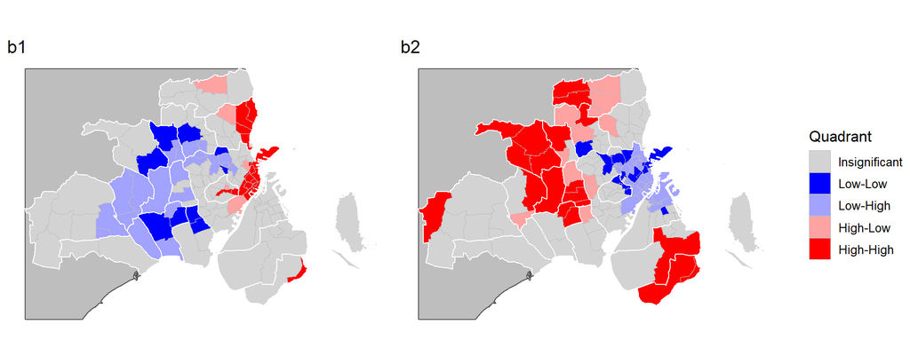

LISA plot for each balance

```r
p1 <- f_local_moran(df = cptl_prsh_ancestry_sf,
              year = 2020,
              variable = "b1",
              signif = 0.1)

p2 <- f_local_moran(df = cptl_prsh_ancestry_sf,
              year = 2020,
              variable = "b2",
              signif = 0.1)

p1 + p2 + plot_layout(guides = "collect")
```

### Hierarchical cluster:

```r
# Dissimilarity matrix
d <- cptl_prsh_ancestry_sf %>%
  select(b1, b2) %>%
  as_tibble() %>%
  select(-geometry) %>%
  scale() %>%
  dist(method = "euclidean")

# Hierarchical clustering
hcl <- hclust(d, method = "ward.D2")

# Add four Clusters
cptl_prsh_ancestry_sf <- cptl_prsh_ancestry_sf %>%
  mutate(CL2 = cutree(hcl, k = 2),
         CL3 = cutree(hcl, k = 3),
         CL4 = cutree(hcl, k = 4)) %>%
  mutate(across(.cols = c(CL2, CL3, CL4), .fns = factor))
```

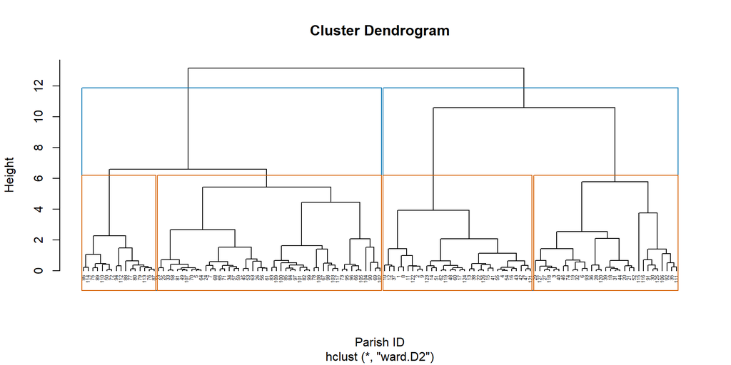

Cluster dendrogram

```r
# Plot
plot(hcl, hang = -1, cex = 0.4, xlab = "Parish ID")
rect.hclust(hcl, k = 2, border = "#0072B2")
rect.hclust(hcl, k = 4, border = "#D55E00")
```

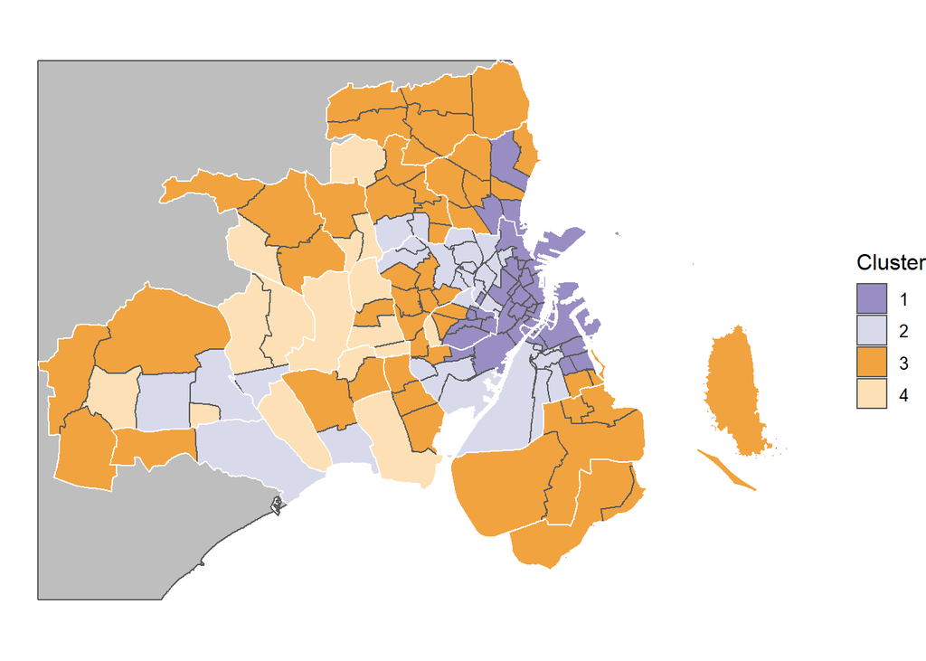

Clusters based on balances (b1 amd b2)

```r
pCL2 <- cptl_prsh_ancestry_sf %>%
  ggplot() +
  geom_sf(data = dk_country_crop, fill = "grey") +
  geom_sf(aes(fill = CL2)) +
  geom_sf(data = cptl_muni, fill = NA, color = "white", size = 0.5) +
  scale_fill_manual(name = "Cluster",
                    values = c("#542788",
                               "#B35806")) +
  geom_sf(data = cptl_muni, fill = NA, color = "white", size = 0.5) +
  theme_void()

pCL3 <- cptl_prsh_ancestry_sf %>%
  ggplot() +
  geom_sf(data = dk_country_crop, fill = "grey") +
  geom_sf(aes(fill = CL3)) +
  geom_sf(data = cptl_muni, fill = NA, color = "white", size = 0.5) +
  scale_fill_manual(name = "Cluster",
                    values = c("#998EC3",
                               "#D8DAEB",
                               "#B35806")) +
  geom_sf(data = cptl_muni, fill = NA, color = "white", size = 0.5) +
  theme_void()

pCL4 <- cptl_prsh_ancestry_sf %>%
  ggplot() +
  geom_sf(data = dk_country_crop, fill = "grey") +
  geom_sf(aes(fill = CL4)) +
  geom_sf(data = cptl_muni, fill = NA, color = "white", size = 0.5) +
  scale_fill_manual(name = "Cluster",
                    values = c("#998EC3",
                               "#D8DAEB",
                               "#F1A340",
                               "#FEE0B6")) +
  geom_sf(data = cptl_muni, fill = NA, color = "white", size = 0.5) +
  theme_void()

pCL4
```

Compositional means of the clusters:

```r
CL4_comp_means <- cptl_prsh_ancestry_sf %>%
  as_tibble() %>%
  select(CL4, pop_dan_pct,  pop_frgn_wst_pct,   pop_frgn_nwst_pct,  -geometry) %>%
  group_split(CL4, .keep = FALSE) %>%
  map(., ~alr(.)) %>%
  map(., ~mean(.)) %>%
  map_dfr(., ~alrInv(.)) %>%
  mutate(CL4 = factor(c(1, 2, 3, 4))) %>%
  select(CL4, everything()) %>%
  mutate(across(where(is.numeric), ~ .x * 100))

CL4_comp_means %>%
  kbl(caption = "Compositional means of the clusters",
      col.names = c("Cluster", "Danes", "Western", "Non-Western"),
      digits = 1) %>%
  kable_styling()
```

Compositional means of the clusters

| Cluster | Danes | Western | Non-Western |
| --- | --- | --- | --- |
| 1 | 81.0 | 11.2 | 7.8 |
| 2 | 66.6 | 9.3 | 24.1 |
| 3 | 85.9 | 5.2 | 8.9 |
| 4 | 74.8 | 4.7 | 20.5 |

Population statistics (in percentage) by clusters (k = 4):

```r
# Create variable labels of the variables to be printed in the table
labelled::var_label(cptl_prsh_ancestry_sf$pop_dan_pct)       <- "Danes"
labelled::var_label(cptl_prsh_ancestry_sf$pop_frgn_wst_pct)  <- "Western"
labelled::var_label(cptl_prsh_ancestry_sf$pop_frgn_nwst_pct) <- "Non-Western"

# table
cptl_prsh_ancestry_sf %>%
  as_tibble() %>%
  select(CL4, pop_dan_pct,  pop_frgn_wst_pct,   pop_frgn_nwst_pct,  -geometry) %>%
  tbl_summary(by = CL4,
              type = all_continuous() ~ "continuous2",
              statistic = all_continuous() ~ c("{mean}",
                                               "{median}",
                                               "{p25} - {p75}",
                                               "{min} - {max}"),
              missing = "no",
              digits = all_continuous() ~ 1) %>%
  bold_labels()
```

| **Characteristic** | **1**, N = 32 | **2**, N = 31 | **3**, N = 48 | **4**, N = 16 |
| --- | --- | --- | --- | --- |
| Danes |  |  |  |  |
| Mean | 80.6 | 65.3 | 85.1 | 74.5 |
| Median | 81.1 | 69.2 | 84.6 | 74.1 |
| IQR | 78.4 - 82.9 | 62.3 - 71.8 | 83.1 - 88.3 | 71.7 - 78.6 |
| Range | 72.9 - 85.6 | 21.2 - 78.7 | 77.3 - 94.6 | 68.0 - 80.3 |
| Western |  |  |  |  |
| Mean | 11.5 | 9.2 | 5.3 | 4.8 |
| Median | 10.4 | 8.9 | 5.5 | 4.6 |
| IQR | 9.5 - 12.3 | 7.7 - 10.1 | 4.4 - 6.4 | 4.4 - 5.5 |
| Range | 8.3 - 19.9 | 4.9 - 14.2 | 2.7 - 7.9 | 3.2 - 6.4 |
| Non-Western |  |  |  |  |
| Mean | 7.9 | 25.5 | 9.6 | 20.7 |
| Median | 7.4 | 21.0 | 9.9 | 21.1 |
| IQR | 6.4 - 9.0 | 16.0 - 30.5 | 7.3 - 11.9 | 17.3 - 23.4 |
| Range | 4.9 - 11.6 | 12.0 - 69.9 | 2.7 - 16.0 | 15.2 - 27.2 |

Box-plot:

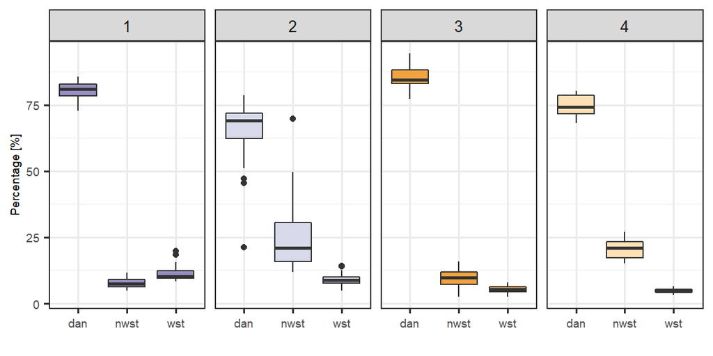

Boxplots of the population structure in each cluster

```r
cptl_prsh_ancestry_sf %>%
  select(CL4, pop_dan_pct, pop_frgn_nwst_pct, pop_frgn_wst_pct) %>%
  as_tibble() %>%
  pivot_longer(!c(CL4, geometry),
               names_to = "name",
               values_to = "value") %>%
  mutate(name = gsub("pop_", "", name),
         name = gsub("_pct", "", name),
         name = gsub("frgn_", "", name))  %>%
  ggplot() +
  geom_boxplot(aes(y = value, x = name, fill = CL4)) +
  scale_fill_manual(name = "Cluster",
                    values = c("#998EC3",
                               "#D8DAEB",
                               "#F1A340",
                               "#FEE0B6")) +
  labs(x = "",
       y = "Percentage [%]")  +
  theme(legend.position = "none") +
  facet_grid(~CL4)
```

Cluster (k = 4) vs. house prices:

```r
sum_runits_oft_prices <- as_tibble(sum_runits_oft_prices) %>%
  # Add balances and clusters
  left_join(as_tibble(cptl_prsh_ancestry_sf)) %>%
  droplevels()

sum_runits_oft_prices %>%
  select(CL4, mean_kDKK_m2, median_kDKK_m2, -geometry) %>%
  tbl_summary(by = CL4,
              type = all_continuous() ~ "continuous2",
              statistic = all_continuous() ~ c("{mean}",
                                               "{median}",
                                               "{p25} - {p75}",
                                               "{min} - {max}"),
              missing = "no",
              digits = all_continuous() ~ 1) %>%
  bold_labels()
```

| **Characteristic** | **1**, N = 32 | **2**, N = 29 | **3**, N = 48 | **4**, N = 16 |
| --- | --- | --- | --- | --- |
| Mean (kDKK/m2) |  |  |  |  |
| Mean | 119.8 | 82.9 | 65.7 | 59.9 |
| Median | 57.0 | 41.7 | 38.2 | 27.2 |
| IQR | 50.7 - 98.7 | 37.3 - 60.8 | 31.4 - 49.8 | 24.8 - 33.5 |
| Range | 39.4 - 1,132.9 | 22.1 - 554.6 | 22.2 - 554.7 | 22.5 - 333.6 |
| Median (kDKK/m2) |  |  |  |  |
| Mean | 67.6 | 37.3 | 35.8 | 50.9 |
| Median | 50.7 | 38.6 | 35.6 | 27.0 |
| IQR | 46.9 - 54.5 | 34.2 - 42.0 | 30.1 - 40.2 | 24.7 - 32.0 |
| Range | 37.1 - 602.6 | 0.4 - 70.8 | 20.5 - 55.6 | 5.1 - 367.3 |

Ternary diagram with house prices and clusters (zoom the figure to the parishes with median values).

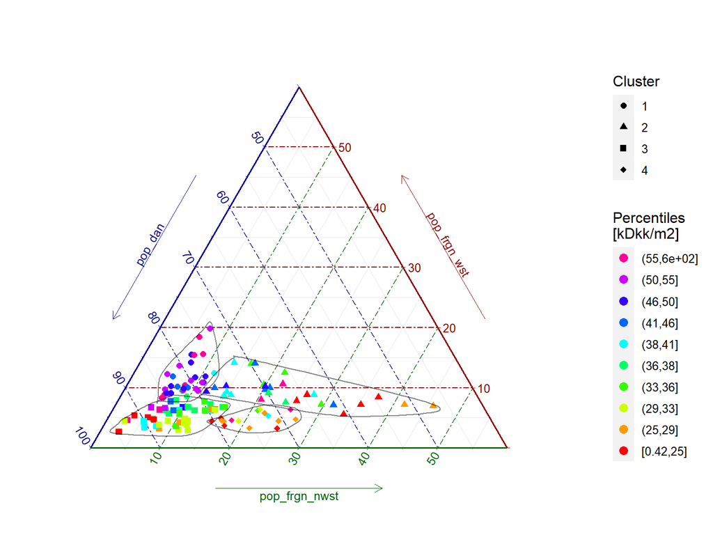

Ternary diagram of population distribution vs. housing prices

```r
ggtern::ggtern(data = sum_runits_oft_prices,
               aes(x = pop_dan,
                   y = pop_frgn_wst,
                   z = pop_frgn_nwst,
                   shape = CL4,
                   colour = cut_number(median_kDKK_m2,
                                       n = 10,
                                       dig.lab = 0))) +
  scale_colour_manual(name = "Percentiles\n[kDkk/m2]",
                         values = rainbow(10)) +
  scale_shape_manual(name = "Cluster",
                     values = c(16, 17, 15, 18)) +
  geom_point(size = 2) +
  ggtern::theme_rgbw() +
  ggtern::theme_hidetitles() +
  ggtern::theme_zoom_L(0.6) +
  guides(colour = guide_legend(reverse = TRUE,
                               override.aes = list(size = 3))) +
  ggalt::geom_encircle(data = sum_runits_oft_prices,
                       aes(x = pop_dan,
                           y = pop_frgn_wst,
                           z = pop_frgn_nwst,
                           shape = CL4),
                       size = 1,
                       alpha = 0.5,
                       expand = 0.01,
                       inherit.aes = FALSE)
```

### Linear model

```r
# Compositional data with prices
dat_acomp_prices <- sum_runits_oft_prices %>%
  select(prsh_id, median_kDKK_m2, pop_dan, pop_frgn_nwst, pop_frgn_wst) %>%
  rename(dan = pop_dan,
         nwst = pop_frgn_nwst,
         wst = pop_frgn_wst) %>%
  as_tibble() %>%
  drop_na() %>%
  # Close dataset
  clo(parts = c("dan", "nwst", "wst"),
      total = 100) %>%
  # CoDa
  acomp()

# First balance ratio nwst/dan+wst
bal1   <- balance(dat_acomp_prices , ~dan/wst/nwst) %>% as_tibble() %>% janitor::clean_names()
dat_m1 <- sum_runits_oft_prices  %>% bind_cols(bal1)
lm1    <- lm(log(median_kDKK_m2) ~ danwst_nwst  + dan_wst, data = dat_m1)

# First balance ratio wst/dan+nwst
bal2   <- balance(dat_acomp_prices , ~dan/nwst/wst) %>% as_tibble() %>% janitor::clean_names()
dat_m2 <- sum_runits_oft_prices  %>% bind_cols(bal2)
lm2    <- lm(log(median_kDKK_m2) ~ dannwst_wst  + dan_nwst, data = dat_m2)

# First balance ratio dan/wst+nwst
bal3   <- balance(dat_acomp_prices , ~nwst/wst/dan) %>% as_tibble() %>% janitor::clean_names()
dat_m3 <- sum_runits_oft_prices  %>% bind_cols(bal3)
lm3    <- lm(log(median_kDKK_m2) ~ nwstwst_dan  + nwst_wst, data = dat_m3)
```

Regression coefficients:

```r
slm1 <- summary(lm1) %>% prettify()
slm2 <- summary(lm2) %>% prettify()
slm3 <- summary(lm3) %>% prettify()

bind_rows(slm1[2,], slm2[2,], slm3[2,]) %>%
  rename(model = " ") %>%
  mutate(model = case_when(
    model == "danwst_nwst" ~ "Model 1 (dan & wst vs. nwst)",
    model == "dannwst_wst" ~ "Model 2 (dan & nwst vs. wst)",
    model == "nwstwst_dan" ~ "Model 3 (nwst & wst vs. dan)"
  )) %>%
  kbl(caption = "Regression coefficient (β) of pivot coordinates",
      digits = 3) %>%
  kable_styling()
```

Regression coefficient (ß) of pivot coordinates

| model | Estimate | CI (lower) | CI (upper) | Std. Error | t value | Pr(>\|t\|) |  |
| --- | --- | --- | --- | --- | --- | --- | --- |
| Model 1 (dan & wst vs. nwst) | 0.359 | 0.166 | 0.551 | 0.097 | 3.683 | <0.001 | *** |
| Model 2 (dan & nwst vs. wst) | -0.430 | -0.699 | -0.162 | 0.136 | -3.170 | 0.002 | ** |
| Model 3 (nwst & wst vs. dan) | 0.072 | -0.217 | 0.360 | 0.146 | 0.494 | 0.622 |  |

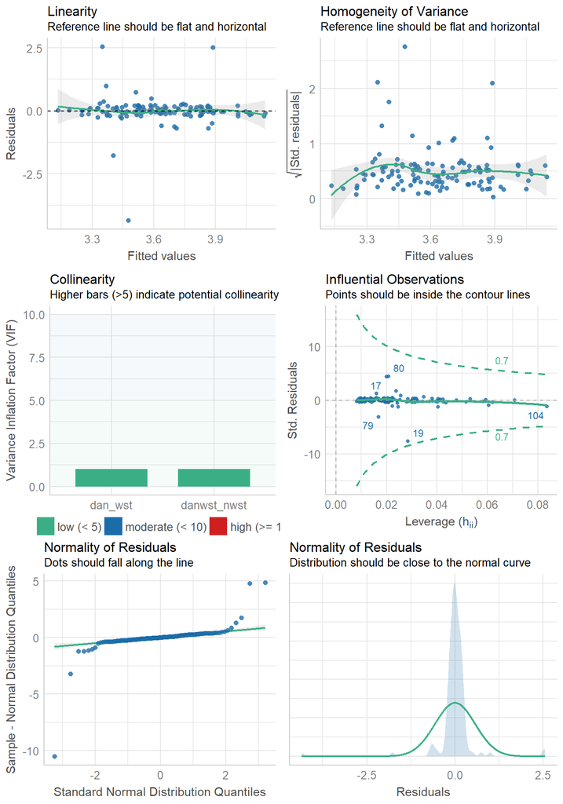

```r
check_model(lm1)
```

Values vs. predictions:

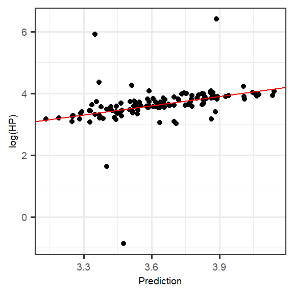

Predictions based on balances (b1 and b2) vs. median values (red line: x = y)

```r
sum_runits_oft_prices$pred1 <- predict(lm1)

ggplot() +
  geom_point(data = sum_runits_oft_prices,
             aes(x = pred1,
                 y = log(median_kDKK_m2))) +
  scale_x_continuous(name = "Prediction") +
  scale_y_continuous(name = "log(HP)") +
  geom_abline(intercept = 0,
              slope = 1,
              colour = "red")
```

Predicted heat outcome:

```r
## Heat map (ternary diagram)
# Compute a grid of points in the simplex space
dan <- wst <- seq(0.5, 99.5, length.out = 100)
df <- expand_grid(dan = dan, wst = wst) %>%
  mutate(nwst = 100 - dan - wst) %>%
  filter(nwst >= 0)

# ilr transformation to transform into a prediction grid on real space
df_bal <- df %>%
  # Close dataset
  clo(parts = c("dan", "wst", "nwst"),
      total = 100) %>%
  # CoDa
  acomp() %>%
  # Balances
  balance(~dan/wst/nwst) %>%
  as_tibble() %>%
  janitor::clean_names()

df <- df %>% bind_cols(df_bal)

# Predict the outcome (with model 1)
df_pred <- predict(lm1, newdata = df, se.fit = TRUE)
df <- bind_cols(df, df_pred)

# Back-transform prediction to the original scale
df <- df %>%
     mutate(fit_LCI = fit - 1.96 * sqrt(0.5 * se.fit^2),
            fit_UCI = fit + 1.96 * sqrt(0.5 * se.fit^2),
            # back-transform
            HP_pred = exp(fit + 0.5*se.fit^2),
            HP_LCI  = exp(fit_LCI + 0.5*se.fit^2),
            HP_UCI  = exp(fit_UCI + 0.5*se.fit^2)
     )

## Transects for piloting predictions along with 95% confidence intervals at
# e.g. Start in the mean composition (D = 80%, wst = 7.5%; nwst = 12.5%)

# a) HP variation with nwst when log-ratio(dan/wst) = log(80/7.5) = c1
c1 <- log(80/7.5)
tran1 <- tibble(name = "tran1",
                nwst = seq(1, 99, 1),
                wst = (100 - nwst)/(1 + exp(c1)),
                dan = 100 - nwst - wst)

# b) HP variation with wst when log-ratio(dan/nwst) = log(80/12.5) = c2
c2 <- log(80/12.5)
tran2 <- tibble(name = "tran2",
                wst = seq(1, 99, 1),
                nwst = (100 - wst)/(1 + exp(c2)),
                dan = 100 - nwst - wst)

# Combine in one tibble
tran <- bind_rows(tran1, tran2)

# ilr transformation
tran <- tran %>%
  mutate(danwst_nwst = sqrt(2/3) * log( sqrt(dan * wst) / nwst),
         dan_wst = sqrt(1/2) * log(dan / wst))

# Predictions
tran_pred <- predict(lm1, tran, se.fit = T, level = 0.95) %>%
  as_tibble() %>%
  # back-transform to original scale
  mutate(fit_LCI = fit - 1.96 * sqrt(0.5 * se.fit^2),
         fit_UCI = fit + 1.96 * sqrt(0.5 * se.fit^2),
         # back-transform
         HP_pred = exp(fit + 0.5*se.fit^2),
         HP_LCI  = exp(fit_LCI + 0.5*se.fit^2),
         HP_UCI  = exp(fit_UCI + 0.5*se.fit^2))

# Add predictions to the table
tran <- bind_cols(tran, tran_pred)
```

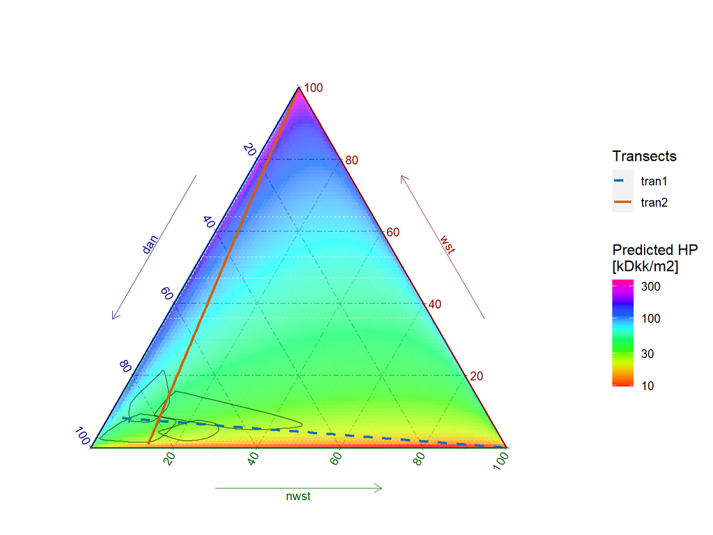

Ternary plot showing the predicted outcome for different compositions

```r
# Ternary plot showing the predicted outcome for different compositions
p <- ggtern(df,aes(dan, wst, nwst)) +
  geom_hex_tern(binwidth  = 0.005,
                aes(value = HP_pred),
                fun = mean,
                alpha = 0.75) +
  scale_fill_gradientn(name = "Predicted HP\n[kDkk/m2]",
                       colours = rainbow(10),
                       trans = "log10") +
  ggtern::theme_rgbw() +
  ggtern::theme_hidetitles() +
  # ggtern::theme_zoom_L(0.6) +
  ggalt::geom_encircle(data = sum_runits_oft_prices,
                       aes(x = pop_dan,
                           y = pop_frgn_wst,
                           z = pop_frgn_nwst,
                           shape = CL4),
                       size = 1,
                       alpha = 0.5,
                       expand = 0.01,
                       inherit.aes = FALSE)

# Add transects
p + geom_line(data = tran,
              aes(x = dan,
                  y = wst,
                  z = nwst,
                  colour = name,
                  linetype = name),
              size = 1) +
  scale_linetype_manual(name = "Transects",
                        values = c("dashed", "solid")) +
  scale_colour_manual(name = "Transects",
                      values = c("#0072B2", "#D55E00"))
```

Predictions with CI:

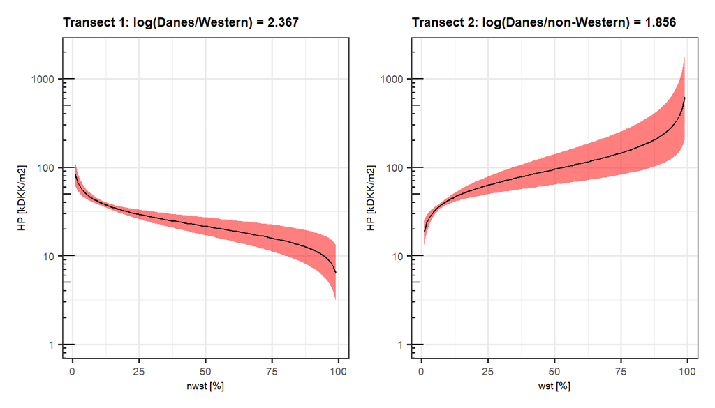

Predicted median house prices at parish level with 95% CI for transects 1 and 2

```r
p1 <- tran %>%
  filter(name == "tran1") %>%
  ggplot(aes(x = nwst, y = HP_pred)) +
  geom_ribbon(aes(ymin = HP_LCI,
                  ymax = HP_UCI),
              alpha = 0.5,
              fill = "red") +
  geom_line() +
  scale_y_log10(limits = c(1, 2000)) +
  labs(title = "Transect 1: log(Danes/Western) = 2.367",
       x = "nwst [%]",
       y = "HP [kDKK/m2]") +
  annotation_logticks(sides = "l")

p2 <- tran %>%
  filter(name == "tran2") %>%
  ggplot(aes(x = wst, y = HP_pred)) +
  geom_ribbon(aes(ymin = HP_LCI,
                  ymax = HP_UCI),
              alpha = 0.5,
              fill = "red") +
  geom_line() +
  scale_y_log10(limits = c(1, 2000)) +
  labs(title = "Transect 2: log(Danes/non-Western) = 1.856",
       x = "wst [%]",
       y = "HP [kDKK/m2]") +
  annotation_logticks(sides = "l")

p1 + p2
```

# Acknowledgements

This work has been financed by Aalborg University - AAU (Project: [Global flows of migrants and their impact on north European welfare states - FLOW](https://www.flow.aau.dk/)). The sole responsibility of this publication lies with the authors. AAU is not responsible for any use that may be made of the information contained therein.

[^1]: Department of Planning, Aalborg University, Copenhagen, Denmark; ORCID: 0000-0003-0624-2345; javierdem@plan.aau.dk - javiereliomedina@gmail.com
[^2]: Department of Planning, Aalborg University, Copenhagen, Denmark; ORCID: 0000-0001-7794-8308; marinag@plan.aau.dk
[^3]: Department of Planning, Aalborg University, Copenhagen, Denmark; ORCID: 0000-0001-7004-0698; hsh@plan.aau.dk
[^4]: Department of Planning, Aalborg University, Copenhagen, Denmark; ORCID: 0000-0002-9724-820X; kessler@plan.aau.dk